# Inequality of Jail Prisoners

Ivy Li

2022-11-19

## Abstract

The US has 5% population of the world but a 25% prisoner population of the world. Prisoners are not treated equally in US prisons. We used a dataset from Vera Inst that contains a lot of detailed data related to US prison. The direct stakeholders can be officials in US Justice Department, family members of prisoners, lawyers, and state/local governments. The indirect stakeholders can be any US citizen or law enforcement people in other countires. The questions that we answer in this report: * Growth of prisoner population in the country and by states. * Prisoner population by gender, race, and geographic area. * Is there a bias (unfairness) to minorities, specially Black/Africa American people.

### Introduction

The US has 5% population of the world but a 25% prisoner population of the world. Prisoners are not treated equally in US prisons. We used a dataset from Vera Inst that contains a lot of detailed data related to US prison. The direct stakeholders can be officials in US Justice Department, family members of prisoners, lawyers, and state/local governments. The indirect stakeholders can be any US citizen or law enforcement people in other countires. The questions that we answer in this report: - Growth of prisoner population in the country and by states. - Prisoner population by gender, race, and geographic area. - Is there a bias (unfairness) to minorities, specially Black/Africa American people.

### Data Summary

```
## [1] "The most recent year is:  2018"
## [1] "Total Population in US is  327167434"
## [1] "Total prisoner in US jail is  737126.07"
## [1] "Total black prisoner in US jail is  247546.95"
## [1] "Average prison population in counties:  248.944974670719"
## [1] 17208
## [1] "The county with highest prison pop:  Los Angeles County"
## [1] 0
## [1] "The counties with lowest prison pop:  Caldwell County"
## [2] "The counties with lowest prison pop:  Lyon County"
## [3] "The counties with lowest prison pop:  Big Stone County"
## [4] "The counties with lowest prison pop:  Stevens County"
## [5] "The counties with lowest prison pop:  Traverse County"
```

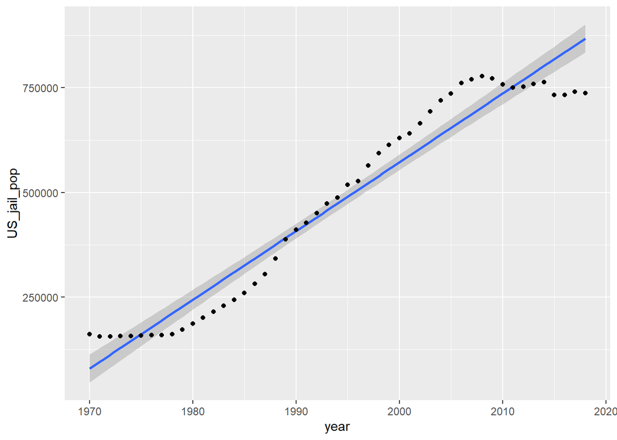

```
## [1] "The US black prison ratio % is:  33.5827153691634"
```

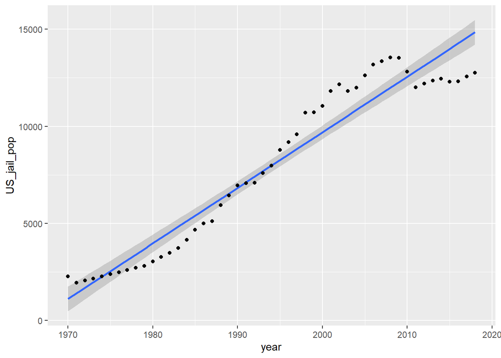

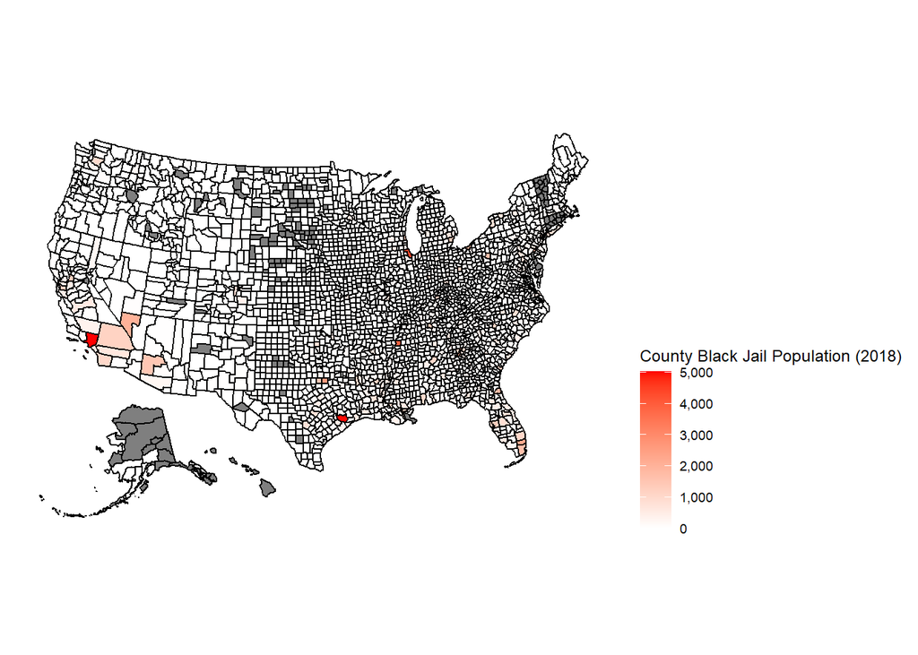

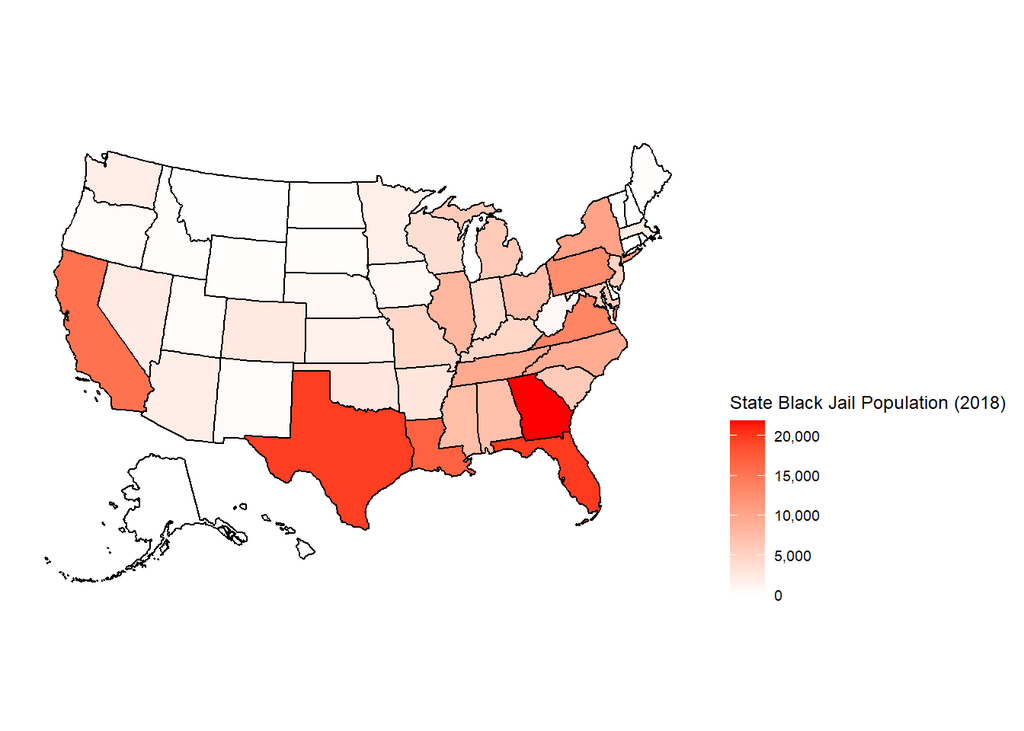